# Hate Crime Final Project Report

PSTAT 131/231

Mitchell Rapaport & Ryan Stofer

# Introduction

The purpose of this project is to generate a model that will predict the offender’s race for a specific hate crime.

## What is a hate crime?

The FBI has defined a hate crime as a “criminal offense against a person or property motivated in whole or in part by an offender’s bias against a race, religion, disability, sexual orientation, ethnicity, gender, or gender identity.” That being said, hate itself is not a crime—and the FBI is mindful of protecting freedom of speech and other civil liberties. Attached below is a video from CNN which clarifies certain misconceptions about hate crimes.

```r
library(vembedr)
embed_url("https://www.youtube.com/watch?v=lZ13i67RoQs")
```

[video not shown]

Specifically, our hate crime data comes from the Hate Crime Statistics Program of the FBI Uniform Crime Reporting (UCR) Program. According to the FBI UCR Program, they collect data regarding criminal offenses that were motivated, in whole or in part, by the offender’s bias against the victim’s race/ethnicity/ancestry, gender, gender identity, religion, disability, or sexual orientation, and were committed against persons, property, or society.

## Why might this model be useful?

There are thousands of unsolved crimes in the USA every year. Any information about a suspect can be a significant factor in their capture. This model can be used to try and predict the race of an unknown suspect when a hate crime is committed, helping to increase the chances of finding them.

## Loading Data and Packages

Our dataset includes 2 different csv files. The first one consists of records of different hate crimes in the USA since 1990. We obtained this dataset from the FBI Crime Data Explorer website: https://crime-data-explorer.fr.cloud.gov/pages/downloads

Our second dataset contains Annual State Resident Population Estimates for 6 Race Groups by Age, Sex, and Hispanic Origin: April 1, 2010 to July 1, 2019. We obtained this dataset from the US census website: https://www.census.gov/data/tables/time-series/demo/popest/2010s-state-detail.html

There are around 236,844 observations with 14 predictors that we can use in this joined dataset.

Key variables:

`DATA_YEAR`: year of crime

`AGENCY_TYPE_NAME`: type of agency that reported the crime, either city or county

`STATE_ABBR`: abbreviation of state where crime was committed

`STATE_NAME`: name of state where crime was committed

`DIVISION_NAME`: geographical division where crime was committed, ex:Pacific

`POPULATION_GROUP_CODE`: group code for population

`TOTAL_OFFENDER_COUNT`: how many people committed the crime

`OFFENDER_RACE`: RESULT VARIABLE: race of the offender

`VICTIM_COUNT`: how many victims there were

`OFFENSE_NAME`: type of crime committed

`LOCATION_NAME`: location of crime, ex: Residence/Home

`BIAS_DESC`: class of the victim/s, ex: gay,black

`VICTIM_TYPES`: type of victim, ex: individual, business, etc.

`POP_STATE`: population of the state in the year when the crime occurred

```r
options(warn=-1)
library(plyr)
library(naivebayes)
library(tidyverse)
```

```r
library(tidyr)
library(ggplot2)
library(reshape2)
library(sjmisc)
library(tree)
library(class)
library(randomForest)
library(gbm)
library(caret)
library(nnet)
library(dplyr)

hate <- read.csv("hate_crime.csv")
census <- read.csv("ARS per state.csv")

set.seed(1234321)
```

# Data Cleaning

We performed the following procedures in cleaning or data:

- Removed unnecessary predictors
- Cleared out NA data Filter our data to 2010-2019
- Transformed all non-numeric values into factors

```r
hate <- hate %>% select(-c("INCIDENT_ID","ORI","PUB_AGENCY_UNIT","REGION_NAME","POPULATION_GROUP_DESC", "ADULT_VICTIM_COUNT","JUVENILE_VICTIM_COUNT","ADULT_OFFENDER_COUNT","JUVENILE_OFFENDER_COUNT","OFFENDER_ETHNICITY","TOTAL_INDIVIDUAL_VICTIMS","MULTIPLE_BIAS","INCIDENT_ID","MULTIPLE_OFFENSE", "INCIDENT_DATE","PUB_AGENCY_NAME"))

# Filters data to only 2010-2019 and removes any observations with unknown offender race
hate <- filter(hate,DATA_YEAR > 2009 & DATA_YEAR < 2020 & OFFENDER_RACE!="Unknown" & OFFENDER_RACE!="")

# Makes all non-numeric columns into factors
hate <- transform(
  hate,
  AGENCY_TYPE_NAME = as.factor(AGENCY_TYPE_NAME),
  STATE_NAME = as.factor(STATE_NAME),
  STATE_ABBR = as.factor(STATE_ABBR),
  DIVISION_NAME = as.factor(DIVISION_NAME),
  POPULATION_GROUP_CODE = as.factor(POPULATION_GROUP_CODE),
  OFFENDER_RACE = as.factor(OFFENDER_RACE),
  OFFENSE_NAME = as.factor(OFFENSE_NAME),
  LOCATION_NAME = as.factor(LOCATION_NAME),
  BIAS_DESC = as.factor(BIAS_DESC),
  VICTIM_TYPES = as.factor(VICTIM_TYPES)
)
```

- Combined relevant data from `census` and added it to `hate`
- Add a new column for each individual type of offense

```r
census$RACE[census$RACE==1]<-"White"
census$RACE[census$RACE==2]<-"Black or African American"
census$RACE[census$RACE==3]<-"American Indian or Alaska Native"
census$RACE[census$RACE==4]<-"Asian"
census$RACE[census$RACE==5]<-"Native Hawaiian or Other Pacific Islander"
census$RACE[census$RACE==6]<-"Multiple"

name_pops = census %>%
  group_by(NAME) %>%
summarise(POPESTIMATE2010=sum(POPESTIMATE2010),      POPESTIMATE2011=sum(POPESTIMATE2011),POPESTIMATE2012=sum(POPESTIMATE2012),POPESTIMATE2013=sum(POPESTIMATE2013),POPESTIMATE2014=sum(POPESTIMATE2014),POPESTIMATE2015=sum(POPESTIMATE2015),POPESTIMATE2016=sum(POPESTIMATE2016),POPESTIMATE2017=sum(POPESTIMATE2017),POPESTIMATE2018=sum(POPESTIMATE2018),POPESTIMATE2019=sum(POPESTIMATE2019))
```

```r
POP_STATE=c()
for (i in 1:nrow(hate)) {
  year = hate[i,"DATA_YEAR"]
  pop_est = paste("POPESTIMATE",as.character(year),sep="")
  state=hate$STATE_NAME[i]
  POP_STATE = append(POP_STATE,as.integer(name_pops[name_pops$NAME==state,pop_est]))
}
hate <- mutate(hate,POP_STATE = POP_STATE)
```

```r
offenses <- unique(hate$OFFENSE_NAME)
single = c()
for (offense in offenses){
  x=as.list(strsplit(offense,";")[[1]])
  for (i in x){
  if (FALSE %in% str_contains(single,i)){
    single <- append(single,i)
  }
 }
}
```

```r
single = sort(single)
for (o in single){
hate[[o]] = grepl(o,hate$OFFENSE_NAME)
}
```

# EDA

## Barplot of Top Offense Types

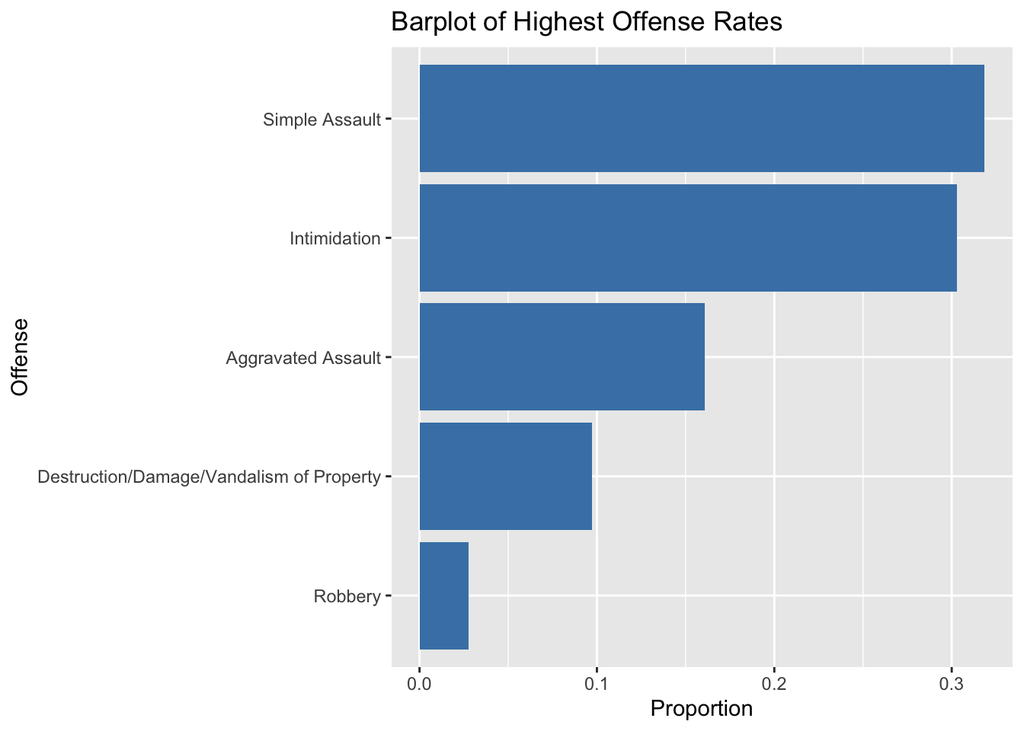

```r
counts = hate %>% select(c(`Aggravated Assault`:`Wire Fraud`)) %>% colSums()

# Creates and orders data for offenses
offense_dist = data.frame(dist=counts/sum(counts),offense=single)
sig_offenses = offense_dist[which(offense_dist$dist>0.02),]
sig_offenses = sig_offenses[order(sig_offenses$dist),]

# Offense Rate Barplot
ggplot(sig_offenses, aes(x=dist, y=reorder(offense,dist))) +
  geom_bar(stat = "identity",fill="steelblue") +
  ggtitle("Barplot of Highest Offense Rates") +
  xlab("Proportion") + ylab("Offense")
```

This shows the rates over all offenses from 2010-2019 of the top 5 of 46 unique offenses. The National Incident-Based Reporting System (NIBRS) defines the following offenses as:

- Aggravated Assault—An unlawful attack by one person upon another wherein the offender uses a weapon or displays it in a threatening manner, or the victim suffers obvious severe or aggravated bodily injury involving apparent broken bones, loss of teeth, possible internal injury, severe laceration, or loss of consciousness. This also includes assault with disease (as in cases when the offender is aware that he/she is infected with a deadly disease and deliberately attempts to inflict the disease by biting, spitting, etc.).
- Simple Assault—An unlawful physical attack by one person upon another where neither the offender displays a weapon, nor the victim suffers obvious severe or aggravated bodily injury involving apparent broken bones, loss of teeth, possible internal injury, severe laceration, or loss of consciousness.
- Intimidation—To unlawfully place another person in reasonable fear of bodily harm through the use of threatening words and/or other conduct, but without displaying a weapon or subjecting the victim to actual physical attack.

## Proportion of all Offense Types

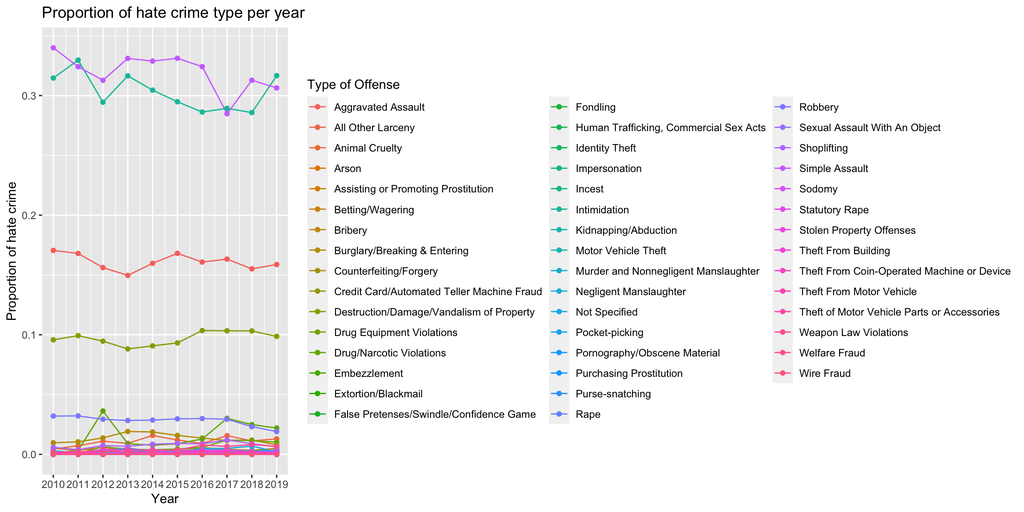

```r
# Calculates proportion of hate crime type per year
o_summary = hate %>% select(c(DATA_YEAR,`Aggravated Assault`:`Wire Fraud`))
res = ddply(o_summary , "DATA_YEAR", function(x) colSums(x[single]))
total=rowSums(res[,2:47])
for (i in single){
  res[[i]]=res[[i]]/total
}

# Melts data with respect to offense names for plotting
mlt_offense = melt(res,id.vars="DATA_YEAR",measure.vars=single)

# Plots Proportion of hate crime type per year
ggplot(mlt_offense, aes(x = DATA_YEAR, y = value, color = variable)) + geom_line() + geom_point() +
  ggtitle("Proportion of hate crime type per year") +
  xlab("Year") + ylab("Proportion of hate crime")  +
  scale_colour_discrete(name = "Type of Offense")+
  scale_x_continuous(breaks=seq(2010,2019,1))
```

This shows proportion of hate crime offense type per year. As we can see, there is general consistency among the years for hate crime offenses. There seems to be an interesting spike in 2012 for one of the offenses colored green, so in the next plot we look more into that.

## Top 6 Offense Type Proportions

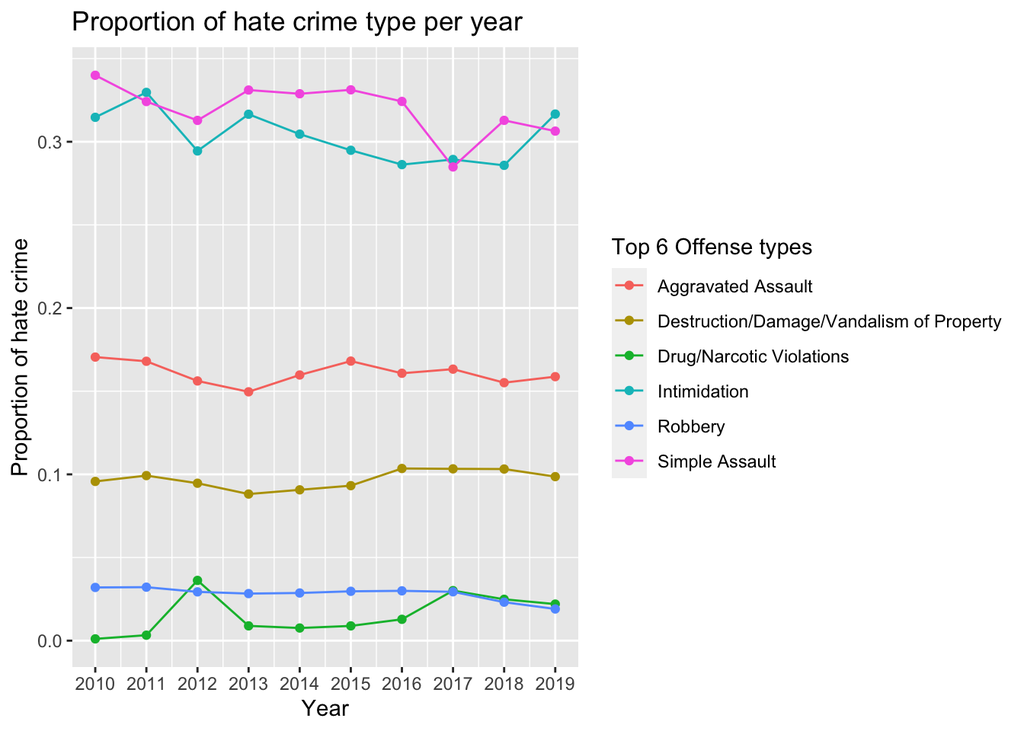

```r
# Filters offense names to only top 6 offenses
spike = mlt_offense[which(mlt_offense$value >0.02),]
offenses6 = unique(spike$variable)
top6 = mlt_offense[which(mlt_offense$variable %in% offenses6),]

# Plots top 6 offenses
ggplot(top6, aes(x = DATA_YEAR, y = value, color = variable)) + geom_line() + geom_point() +
  ggtitle("Proportion of hate crime type per year") +
  xlab("Year") + ylab("Proportion of hate crime")  +
  scale_colour_discrete(name = "Top 6 Offense types")+
  scale_x_continuous(breaks=seq(2010,2019,1))
```

We noticed an interesting spike in one of the offenses in 2012. This level is drugs/narcotics violations, but we do not have any prior knowledge of why there may be a spike in this certain year.

## Offender Race Proportion per year

```r
# Calculates proportion of offender race per year
offenders_summary = hate %>% select(c(DATA_YEAR,OFFENDER_RACE)) %>%
  group_by(DATA_YEAR,OFFENDER_RACE) %>%
  summarise(value = n())
```

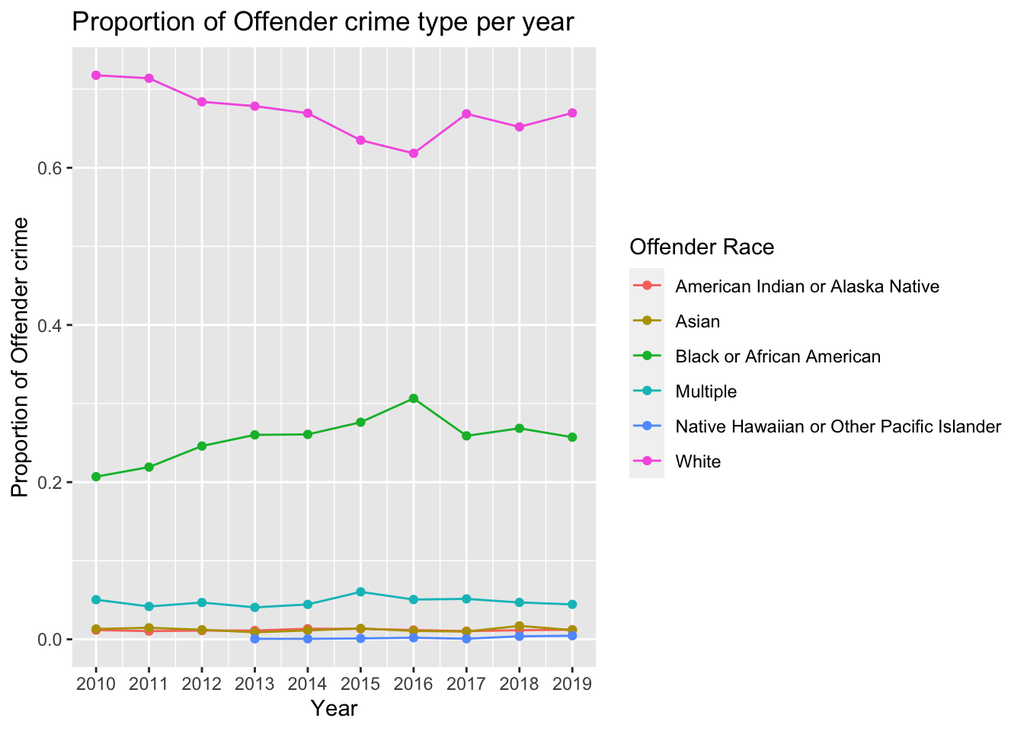

```r
for (year in unique(offenders_summary$DATA_YEAR)){
  cut=offenders_summary[which(offenders_summary$DATA_YEAR==year),]
  total=sum(cut$value)
  offenders_summary$value[offenders_summary$DATA_YEAR==year]<-offenders_summary$value[offenders_summary$DATA_YEAR==year]/total
}

# Plots proportion of offender race per year
ggplot(offenders_summary, aes(x = DATA_YEAR, y = value, color = OFFENDER_RACE)) + geom_line() + geom_point() +
  ggtitle("Proportion of Offender crime type per year") +
  xlab("Year") + ylab("Proportion of Offender crime")  +
  scale_colour_discrete(name = "Offender Race")+
  scale_x_continuous(breaks=seq(2010,2019,1))
```

```r
# Creates new boolean columns for each individual bias
  hate$Black <- grepl("Anti-Black", hate$BIAS_DESC)
  hate$Gay <- grepl("Anti-Gay", hate$BIAS_DESC)
  hate$White <- grepl("Anti-White", hate$BIAS_DESC)
  hate$Islamic <- grepl("Anti-Islamic", hate$BIAS_DESC)
  hate$Mental <- grepl("Anti-Mental", hate$BIAS_DESC)
  hate$Race <- grepl("Race/", hate$BIAS_DESC)
  hate$Mult_Religions <- grepl("Religions", hate$BIAS_DESC)
  hate$Hispanic <- grepl("Anti-Hispanic", hate$BIAS_DESC)
  hate$Religion <- grepl("Anti-Other Religion", hate$BIAS_DESC)
  hate$Asian <- grepl("Anti-Asian", hate$BIAS_DESC)
  hate$Lesbian <- grepl("Anti-Lesbian ", hate$BIAS_DESC)
  hate$Catholic <- grepl("Anti-Catholic", hate$BIAS_DESC)
  hate$LGBT <- grepl("Anti-Lesbian, Gay", hate$BIAS_DESC)
  hate$Mult_Races <- grepl("Anti-Multiple Races", hate$BIAS_DESC)
  hate$Physical <- grepl("Anti-Physical", hate$BIAS_DESC)
  hate$Jewish <- grepl("Anti-Jewish", hate$BIAS_DESC)
  hate$Native <- grepl("Alaska", hate$BIAS_DESC)
  hate$Bisexual <- grepl("Anti-Bisexual", hate$BIAS_DESC)
  hate$Heterosexual <- grepl("Anti-Heterosexual", hate$BIAS_DESC)
  hate$Protestant <- grepl("Anti-Protestant", hate$BIAS_DESC)
  hate$Atheism <- grepl("Anti-Atheism", hate$BIAS_DESC)
  hate$Gender <- grepl("Anti-Gender", hate$BIAS_DESC)
  hate$Female <- grepl("Anti-Female", hate$BIAS_DESC)
  hate$Male <- grepl("Anti-Male", hate$BIAS_DESC)
  hate$Transgender <- grepl("Anti-Trans", hate$BIAS_DESC)
  hate$Islander <- grepl("Anti-Native Hawaii", hate$BIAS_DESC)
  hate$Arab <- grepl("Anti-Arab", hate$BIAS_DESC)
  hate$Buddhist <- grepl("Anti-Buddhist", hate$BIAS_DESC)
  hate$Sikh <- grepl("Anti-Sikh", hate$BIAS_DESC)
  hate$Christian <- grepl("Anti-Other Christian", hate$BIAS_DESC)
  hate$Orthodox <- grepl("Orthodox", hate$BIAS_DESC)
  hate$Hindu <- grepl("Anti-Hindu", hate$BIAS_DESC)
  hate$Mormon <- grepl("Anti-Mormon", hate$BIAS_DESC)
  hate$Jehovah <- grepl("Anti-Jehovah", hate$BIAS_DESC)

# Stores names of all bias types
bias_names <- c("Black","Gay","White","Islamic","Mental","Race",
                "Mult_Religions","Hispanic","Religion","Asian",
                "Lesbian","Catholic","LGBT","Mult_Races","Physical",
                "Jewish","Native","Bisexual","Heterosexual","Protestant",
                "Atheism","Gender","Female","Male","Transgender",
                "Islander","Arab","Buddhist","Sikh","Christian", "Orthodox",
                "Hindu","Mormon","Jehovah")
```

## Bias Desc per Year

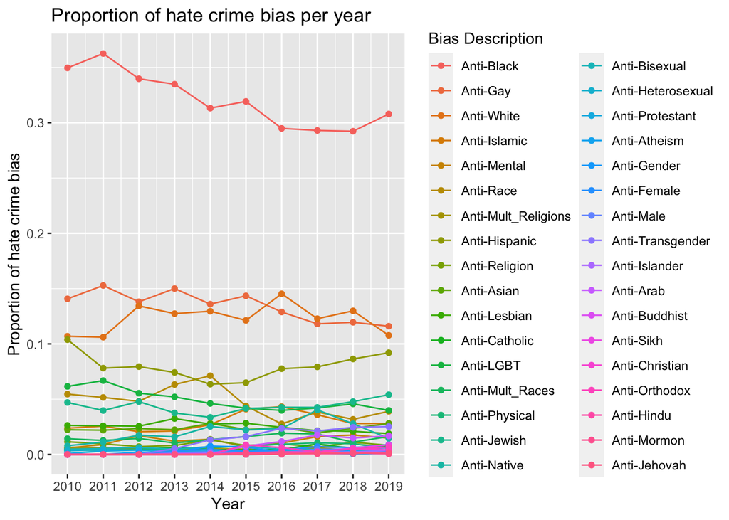

```r
# Calculates proportion of biases
bias_summary = hate %>% select(c(DATA_YEAR, Black:Jehovah))
res = ddply(bias_summary , "DATA_YEAR", function(x) colSums(x[bias_names]))
total = rowSums(res[,2:35])

for (i in bias_names){
  res[[i]]=res[[i]]/total
}

# Melts data with respect to bias names for plotting
melt_bias = melt(res,id.vars="DATA_YEAR", measure.vars= bias_names)

# Plots proportion of hate crime bias per year
ggplot(melt_bias, aes(x = DATA_YEAR, y = value, color = variable)) + geom_line() + geom_point() +
  ggtitle("Proportion of hate crime bias per year") +
  xlab("Year") + ylab("Proportion of hate crime bias")  +
  scale_colour_discrete(name = "Bias Description",
                        labels = paste("Anti-",bias_names,sep="")) +
  scale_x_continuous(breaks=seq(2010,2019,1))
```

```r
# Finds top 5 bias
top_5_bias <- aggregate(melt_bias$value, by=list(Bias=melt_bias$variable), FUN=sum)
top_5_bias <- top_5_bias %>%
    arrange(desc(x)) %>%
    slice(1:5)
head(top_5_bias$Bias)
```

```
## [1] Black    Gay      White    Hispanic LGBT
## 34 Levels: Black Gay White Islamic Mental Race Mult_Religions ... Jehovah
```

This shows the proportion of the type of Bias description from 2010-2019. We see that around 1/3 of hate crimes committed are towards African-American people. Also, we see from the table that the other top biases are Anti-Gay, Anti-White, Anti-Hispanic, and Anti-LGBT.

## Bias Desc Proportion by State

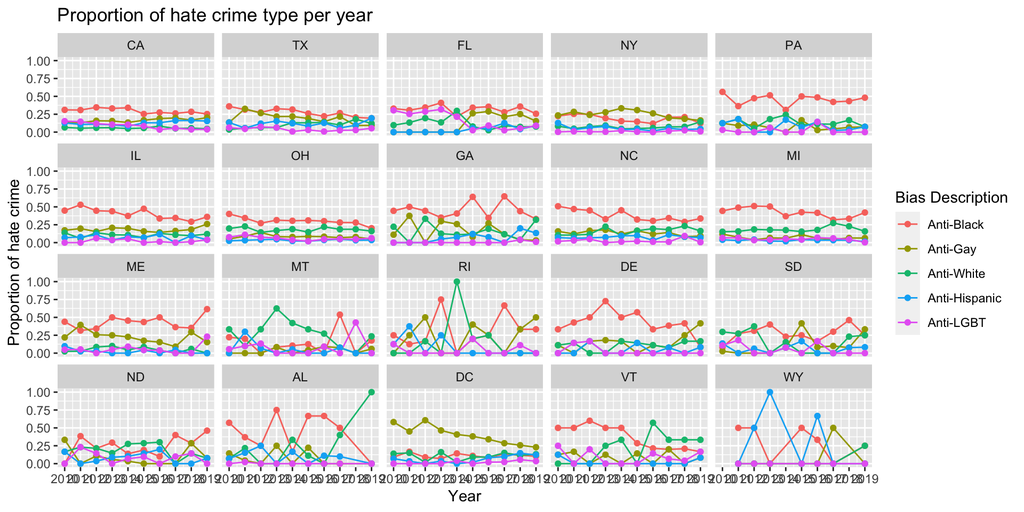

```r
# Calculates proportion of hate crime bias per year
bias_state_summary = hate %>% select(c(DATA_YEAR, STATE_ABBR, Black:Jehovah))
res_state = ddply(bias_state_summary, c("DATA_YEAR","STATE_ABBR"), function(x) colSums(x[bias_names]))

total = rowSums(res_state[,3:36])
for (i in bias_names){
  res_state[[i]]=res_state[[i]]/total
}

# Melts data with respect to bias name for plotting
melt_bias_state = melt(res_state, id.vars=c("DATA_YEAR","STATE_ABBR"), measure.vars= bias_names)

# Selects top 10 most and least populated states
state_bias_1 <- melt_bias_state %>% filter(STATE_ABBR %in%
                                               c("CA", "TX", "FL", "NY", "PA",
                                                 "IL", "OH", "GA", "NC", "MI",
                                                 "WY", "VT", "DC", "AL", "ND",
                                                 "SD", "DE", "RI", "MT", "ME"))

# Filters by top 5 bias
state_bias <- state_bias_1 %>% filter(variable %in% c("Black","Gay","White","Hispanic","LGBT"))

# Orders states by population (top 10 highest and lowest)
state_bias$STATE_ABBR <- factor(state_bias$STATE_ABBR, levels=c("CA","TX","FL","NY","PA",
                                 "IL", "OH", "GA", "NC", "MI",
                                 "ME", "MT", "RI", "DE", "SD",
                                 "ND", "AL", "DC", "VT", "WY"))

# Plots proportion of hate crime bias per year for 20 states
ggplot(state_bias, aes(x = DATA_YEAR, y = value, color = variable)) + geom_line() + geom_point() +
  ggtitle("Proportion of hate crime type per year") +
  xlab("Year") + ylab("Proportion of hate crime")  +
  scale_colour_discrete(name = "Bias Description", labels = c("Anti-Black", "Anti-Gay", "Anti-White","Anti-Hispanic","Anti-LGBT")) +
  scale_x_continuous(breaks=seq(2010,2019,1)) + facet_wrap(~STATE_ABBR)
```

## Heatmap of Offender Race vs Bias Desc

```r
# Calculates proportion of hate crime bias per offender race
offender_bias = hate %>% select(c(OFFENDER_RACE,bias_names))
```

```
## Note: Using an external vector in selections is ambiguous.
## ℹ Use `all_of(bias_names)` instead of `bias_names` to silence this message.
## ℹ See <https://tidyselect.r-lib.org/reference/faq-external-vector.html>.
```

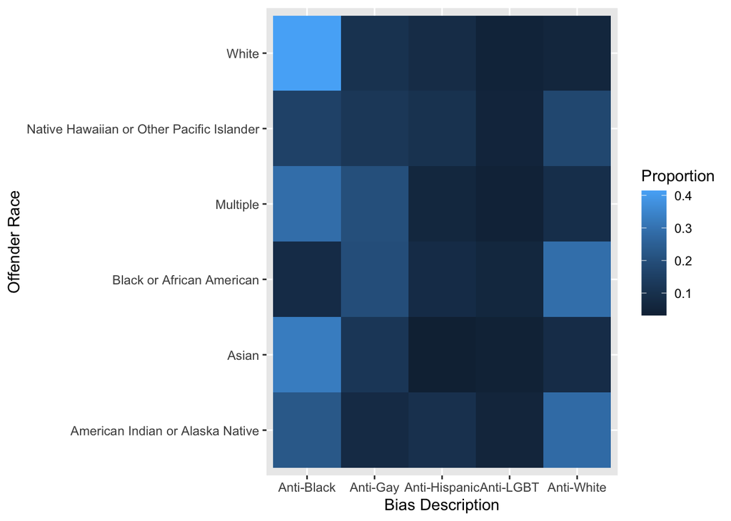

```r
offender_bias_res = ddply(offender_bias , "OFFENDER_RACE", function(x) colSums(x[bias_names]))
ototal=rowSums(offender_bias_res[,2:35])

for (i in bias_names){
  offender_bias_res[[i]]=offender_bias_res[[i]]/ototal
}

# Melts data with respect to bias type
offender_bias_melt = melt(offender_bias_res,id.vars="OFFENDER_RACE",measure.vars=bias_names)

# Filters for top 5 bias
cut_offender_bias <- offender_bias_melt %>% filter(variable %in% c("Black","Gay","White","Hispanic","LGBT"))

cut_offender_bias$variable <- paste("Anti-", cut_offender_bias$variable, sep ="") %>% as.factor()


# Plots heatmap of bias description and offender race
ggplot(cut_offender_bias, aes(variable,OFFENDER_RACE)) +
  scale_fill_gradient(name = "Proportion")+
  geom_tile(aes(fill = value)) + xlab("Bias Description") + ylab("Offender Race")
```

This is a heatmap created to compare the proportion of offender’s race with the top 5 bias descriptions across all hate crimes. We see from this heatmap that there is a high proportion of Anti-Black hate crimes committed by white offenders in comparison to other races.

# Data Pre-processing

Before we created our models, we had to perform a couple of minor data pre-processing actions since which included the following:

- Transform `DATA_YEAR` to a factor (`DATA_YEAR` could not have been plotted on graphs if it were originally a factor)
- Removes state population and all individual offense names and bias description columns (There are observations where the hate crime was on the federal level and would thus have missing values for state population. Also, the individual offense names and bias descriptions are no longer needed)
- Lumps certain factors so that all factors have a maximum of 32 levels (Certain models can not be created if there are >32 factor levels.)
- Removes `STATE_ABBR` as `STATE_NAME` already contains the name of each state

# Test/Train split

```r
# Transforms DATA_YEAR to factor
# Note: If DATA_YEAR was a factor earlier, then it would be unable to plot EDA graphs
hate <- hate %>% transform(DATA_YEAR = as.factor(DATA_YEAR))

# Removes state population, and all individual offense names and bias columns
hate1 = hate %>% select(DATA_YEAR:VICTIM_TYPES)

# Lumps factors so there is only a total of 32
hate1 = hate1 %>% mutate(BIAS_DESC=fct_lump(BIAS_DESC,31),
                         OFFENSE_NAME=fct_lump(OFFENSE_NAME,31),
                         LOCATION_NAME=fct_lump(LOCATION_NAME,31))

# Remove STATE_ABBR because we already have STATE_NAME
hate1 = hate1 %>% select(-STATE_ABBR)

set.seed(1234)
split1<- sample(c(rep(0, 0.7 * nrow(hate1)), rep(1, 0.3 * nrow(hate1))))
train1 <- hate1[split1 == 0, ]
test1 <- hate1[split1== 1, ]

# Hate2 contains both pop_state and pop_name
# Remove STATE_ABBR because we already have STATE_NAME
hate2 = hate %>% select(DATA_YEAR:POP_STATE)
hate2 = hate2 %>% select(-STATE_ABBR)

set.seed(1234)
split2<- sample(c(rep(0, 0.7 * nrow(hate2)), rep(1, 0.3 * nrow(hate2))))
train2 <- hate2[split2 == 0, ]
test2 <- hate2[split2== 1, ]
```

# Model Building & Performance

## Random Forest

```r
rf.hate = randomForest(OFFENDER_RACE ~ ., data=train1, mtry=3, ntree=500, importance=TRUE)
saveRDS(rf.hate,"./RFhate")
```

```r
rf.hate <- readRDS('./RFHATE')
rf.hate
```

```
##
## Call:
##  randomForest(formula = OFFENDER_RACE ~ ., data = train1, mtry = 3,      ntree = 500, importance = TRUE)
##                Type of random forest: classification
##                      Number of trees: 500
## No. of variables tried at each split: 3
##
##         OOB estimate of  error rate: 23.1%
## Confusion matrix:
##                                           American Indian or Alaska Native
## American Indian or Alaska Native                                         6
## Asian                                                                    1
## Black or African American                                                6
## Multiple                                                                 0
## Native Hawaiian or Other Pacific Islander                                0
## White                                                                   10
##                                           Asian Black or African American
## American Indian or Alaska Native              0                        64
## Asian                                         2                        53
## Black or African American                     3                      3661
## Multiple                                      0                       207
## Native Hawaiian or Other Pacific Islander     1                         3
## White                                        10                      1345
##                                           Multiple
## American Indian or Alaska Native                 0
## Asian                                            0
## Black or African American                       13
## Multiple                                       343
## Native Hawaiian or Other Pacific Islander        0
## White                                           31
##                                           Native Hawaiian or Other Pacific Islander
## American Indian or Alaska Native                                                  0
## Asian                                                                             1
## Black or African American                                                         0
## Multiple                                                                          0
## Native Hawaiian or Other Pacific Islander                                         8
## White                                                                             2
##                                           White class.error
## American Indian or Alaska Native            249  0.98119122
## Asian                                       273  0.99393939
## Black or African American                  3093  0.45971074
## Multiple                                    712  0.72820919
## Native Hawaiian or Other Pacific Islander    30  0.80952381
## White                                     16308  0.07895629
```

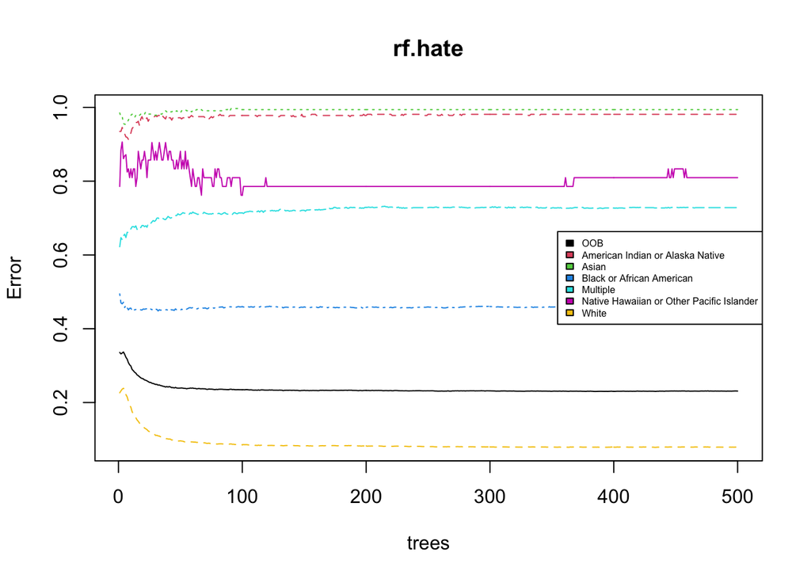

```r
plot(rf.hate,col=1:8)
legend("right", colnames(rf.hate$err.rate),col=1:8,cex=0.5,fill=1:8)
```

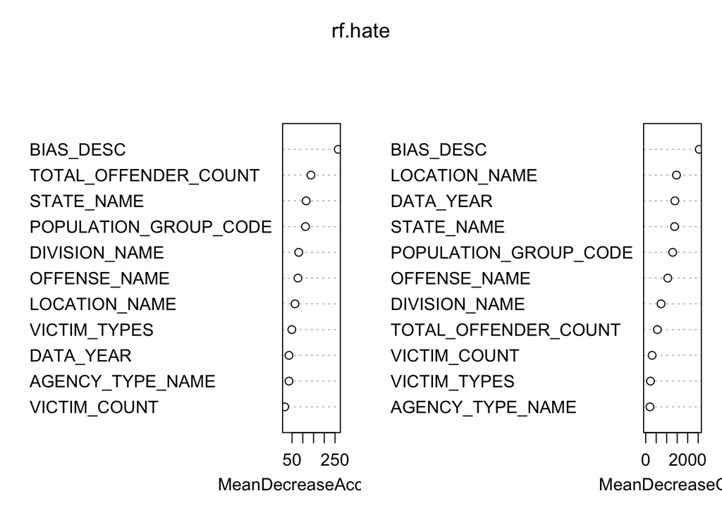

```r
varImpPlot(rf.hate)
```

```r
yhat.rf = predict (rf.hate, newdata = test1)

# Confusion matrix
rf.err = table(pred = yhat.rf, truth = test1$OFFENDER_RACE)
test.rf.err = 1 - sum(diag(rf.err))/sum(rf.err)
test.rf.err
```

```
## [1] 0.2245564
```

```r
importance(rf.hate)
```

```
##                       American Indian or Alaska Native     Asian
## DATA_YEAR                                    10.582006  5.933501
## AGENCY_TYPE_NAME                              7.437208  3.741812
## STATE_NAME                                   24.915504  3.017671
## DIVISION_NAME                                28.512576  5.349347
## POPULATION_GROUP_CODE                        18.664308  9.255485
## TOTAL_OFFENDER_COUNT                          7.901568  4.772830
## VICTIM_COUNT                                 -3.242806 -1.370013
## OFFENSE_NAME                                 11.396921  7.320021
## LOCATION_NAME                                 8.036235  1.394652
## BIAS_DESC                                    18.208704  5.055847
## VICTIM_TYPES                                  8.944477  2.625508
##                       Black or African American   Multiple
## DATA_YEAR                              26.47720  12.034449
## AGENCY_TYPE_NAME                       34.00948   6.474096
## STATE_NAME                             74.65079  56.456105
## DIVISION_NAME                          62.56060  50.891740
## POPULATION_GROUP_CODE                 111.86479  20.604103
## TOTAL_OFFENDER_COUNT                   50.26624 212.316469
## VICTIM_COUNT                           11.37626  31.496834
## OFFENSE_NAME                           48.34888  24.947727
## LOCATION_NAME                          49.00393  26.669063
## BIAS_DESC                             251.00599  20.966959
## VICTIM_TYPES                           30.69115   7.958314
##                       Native Hawaiian or Other Pacific Islander      White
## DATA_YEAR                                             13.103787  19.581691
## AGENCY_TYPE_NAME                                       5.511092  22.682042
## STATE_NAME                                            26.785864  75.903632
## DIVISION_NAME                                         21.225176  59.105963
## POPULATION_GROUP_CODE                                 24.625036  62.809339
## TOTAL_OFFENDER_COUNT                                   1.785684  60.240395
## VICTIM_COUNT                                           3.015161   1.073545
## OFFENSE_NAME                                          12.942345  62.558097
## LOCATION_NAME                                          5.691748  36.353858
## BIAS_DESC                                              9.015870 194.063757
## VICTIM_TYPES                                          10.448798  39.278187
##                       MeanDecreaseAccuracy MeanDecreaseGini
## DATA_YEAR                         35.84444        1390.3156
## AGENCY_TYPE_NAME                  35.77956         201.9525
## STATE_NAME                       115.58874        1375.4897
## DIVISION_NAME                     81.19732         731.4104
## POPULATION_GROUP_CODE            112.58241        1284.0357
## TOTAL_OFFENDER_COUNT             137.99882         556.7265
## VICTIM_COUNT                      15.97339         304.4666
## OFFENSE_NAME                      77.53460        1050.8930
## LOCATION_NAME                     63.69533        1464.7316
## BIAS_DESC                        265.04691        2549.7304
## VICTIM_TYPES                      48.93245         225.8989
```

For our random forest model, we set `mtry=3` since the model took 30min to process! We used data from the first split as there are too many factor levels for all state variables. Cross-validation is not needed to evaluate the accuracy of our model since we can use the Out-of-bag error to assess the accuracy of our model. We see that the Random Forest model has performed successfully well with having only ~23% error rate! We see that `BIAS_DESC`, `LOCATION_NAME`, and `DATA_YEAR` are the top 3 importance factors for our random forest. Furthermore, we see from the plotted random forest model that there is an extremely small error accuracy for predicting white offenders and a somewhat reasonable error accuracy for predicting black offenders, but a high error rate for other racial groups.

## Boosting

```r
k.boost.folds1 <- function(k) {
      models.dt <- vector(mode='list',length=k)
      accuracies.dt <- c()
      folds <- createFolds(train1$OFFENDER_RACE, k = k, list = TRUE, returnTrain = TRUE)
      for (i in 1:k) {
        model <- gbm(OFFENDER_RACE~.,data=train1[folds[[i]],],
                 distribution="multinomial", n.trees=500, interaction.depth=4)
        yhat.boost = predict(model, newdata = train1[-folds[[i]],],n.trees=500)
        yhat.boost = as.matrix(yhat.boost[,,1])
        yhat.boost = yhat.boost %>% cbind(max_ind=colnames(yhat.boost)[max.col(yhat.boost[,1:6])])
        # Confusion matrix
        boost.err = table(pred = yhat.boost[,7], truth = train1[-folds[[i]],]$OFFENDER_RACE)
        fold.boost.err = 1 - sum(diag(boost.err))/sum(boost.err)
        accuracies.dt <- append(accuracies.dt, fold.boost.err)
        models.dt[[i]]<-model

      }
      return (list(models.dt,accuracies.dt))
    }
```

```r
CVB1 <- k.boost.folds1(5)
saveRDS(CVB1,"./BOOSThate1")
```

```r
CVB1 <- readRDS('./BOOSTHATE1')
```

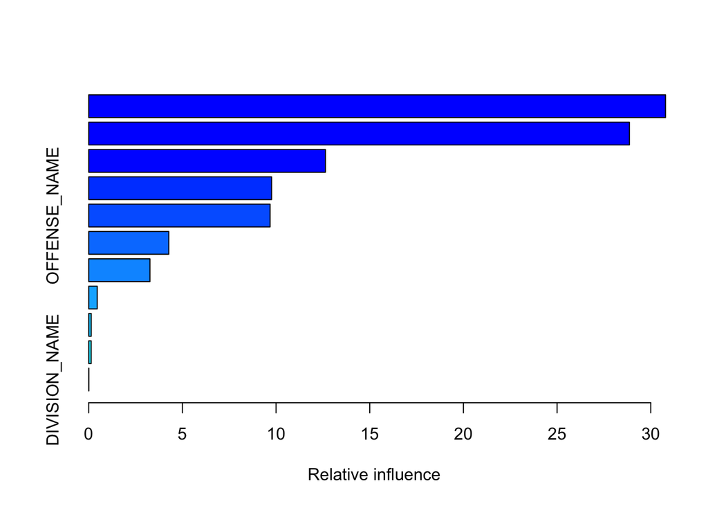

```
##                                         var      rel.inf
## BIAS_DESC                         BIAS_DESC 30.787800042
## STATE_NAME                       STATE_NAME 28.860338357
## LOCATION_NAME                 LOCATION_NAME 12.636660357
## POPULATION_GROUP_CODE POPULATION_GROUP_CODE  9.762290276
## OFFENSE_NAME                   OFFENSE_NAME  9.680884942
## TOTAL_OFFENDER_COUNT   TOTAL_OFFENDER_COUNT  4.274580357
## DATA_YEAR                         DATA_YEAR  3.268662520
## VICTIM_TYPES                   VICTIM_TYPES  0.455041071
## VICTIM_COUNT                   VICTIM_COUNT  0.134045881
## AGENCY_TYPE_NAME           AGENCY_TYPE_NAME  0.131283781
## DIVISION_NAME                 DIVISION_NAME  0.008412416
```

```r
best_boost_index1 = which.min(CVB1[[2]])
best_boost1 = CVB1[[1]][[best_boost_index1]]
summary(best_boost1)
```

```r
boost_pred1 <- predict(best_boost1,newdata=test1)
yhat.boost1 = as.matrix(boost_pred1[,,1])
yhat.boost1 = yhat.boost1 %>% cbind(max_ind=colnames(yhat.boost1)[max.col(yhat.boost1[,1:6])])
# Confusion matrix
boost.err1 = table(pred = yhat.boost1[,7], truth = test1$OFFENDER_RACE)
test.boost.err1 = 1 - sum(diag(boost.err1))/sum(boost.err1)
test.boost.err1
```

```
## [1] 0.2344426
```

```r
k.boost.folds2 <- function(k) {
      models.dt <- vector(mode='list',length=k)
      accuracies.dt <- c()
      folds <- createFolds(train2$OFFENDER_RACE, k = k, list = TRUE, returnTrain = TRUE)
      for (i in 1:k) {
        model <- gbm(OFFENDER_RACE~.,data=train2[folds[[i]],],
                 distribution="multinomial", n.trees=500, interaction.depth=4)
        yhat.boost = predict(model, newdata = train2[-folds[[i]],],n.trees=500)
        yhat.boost = as.matrix(yhat.boost[,,1])
        yhat.boost = yhat.boost %>% cbind(max_ind=colnames(yhat.boost)[max.col(yhat.boost[,1:6])])
        # Confusion matrix
        boost.err = table(pred = yhat.boost[,7], truth = train2[-folds[[i]],]$OFFENDER_RACE)
        fold.boost.err = 1 - sum(diag(boost.err))/sum(boost.err)
        accuracies.dt <- append(accuracies.dt, fold.boost.err)
        models.dt[[i]]<-model

      }
      return (list(models.dt,accuracies.dt))
    }
```

```r
CVB2 <- k.boost.folds2(5)
saveRDS(CVB2,"./BOOSThate2")
```

```r
CVB2 <- readRDS('./BOOSTHATE2')
```

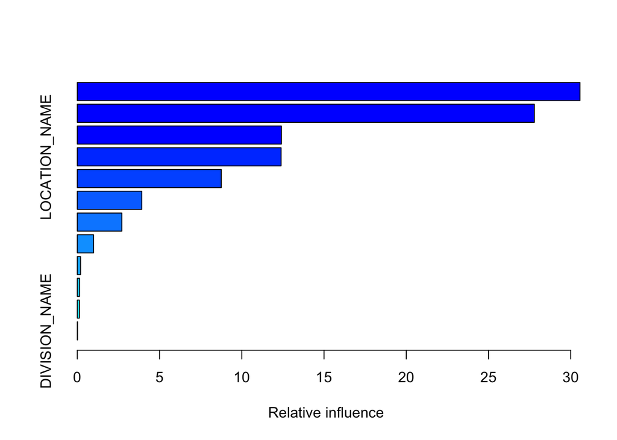

```
##                                         var     rel.inf
## BIAS_DESC                         BIAS_DESC 30.56277473
## STATE_NAME                       STATE_NAME 27.78859752
## OFFENSE_NAME                   OFFENSE_NAME 12.40788662
## LOCATION_NAME                 LOCATION_NAME 12.39146485
## POPULATION_GROUP_CODE POPULATION_GROUP_CODE  8.75220542
## TOTAL_OFFENDER_COUNT   TOTAL_OFFENDER_COUNT  3.92029627
## DATA_YEAR                         DATA_YEAR  2.70771694
## POP_STATE                         POP_STATE  0.99024408
## VICTIM_COUNT                   VICTIM_COUNT  0.19855614
## VICTIM_TYPES                   VICTIM_TYPES  0.13893298
## AGENCY_TYPE_NAME           AGENCY_TYPE_NAME  0.12742286
## DIVISION_NAME                 DIVISION_NAME  0.01390158
```

```r
best_boost_index2 = which.min(CVB2[[2]])
best_boost2 = CVB2[[1]][[best_boost_index2]]
summary(best_boost2)
```

```r
boost_pred2 <- predict(best_boost2,newdata=test2)
yhat.boost2 = as.matrix(boost_pred2[,,1])
yhat.boost2 = yhat.boost2 %>% cbind(max_ind=colnames(yhat.boost2)[max.col(yhat.boost2[,1:6])])
# Confusion matrix
boost.err2 = table(pred = yhat.boost2[,7], truth = test2$OFFENDER_RACE)
test.boost.err2 = 1 - sum(diag(boost.err2))/sum(boost.err2)
test.boost.err2
```

```
## [1] 0.2336482
```

## Logistic Regression

```r
k.LR.folds1 <- function(k) {
      models.dt <- vector(mode='list',length=k)
      accuracies.dt <- c()
      folds <- createFolds(train1$OFFENDER_RACE, k = k, list = TRUE, returnTrain = TRUE)
      for (i in 1:k) {
        model <- multinom(OFFENDER_RACE~.,data=train1[folds[[i]],],MaxNWts=10000)
        predictions <- predict(object = model, newdata = train1[-folds[[i]],], type = "class")
        LR.err = table(pred = predictions, truth = train1[-folds[[i]],]$OFFENDER_RACE)
        fold.LR.err = 1 - sum(diag(LR.err))/sum(LR.err)
        accuracies.dt <- append(accuracies.dt, fold.LR.err)
        models.dt[[i]]<-model
      }
      return (list(models.dt,accuracies.dt))
    }
```

```r
CVLR1 <- k.LR.folds1(5)
saveRDS(CVLR1,"./LRhate1")
```

```r
CVLR1 <- readRDS('./LRHATE1')
```

```r
best_LR_index1 = which.min(CVLR1[[2]])
best_LR1 = CVLR1[[1]][[best_LR_index1]]
LR_pred1 <- predict(best_LR1,newdata=test1)
LR.err1 = table(pred = LR_pred1, truth = test1$OFFENDER_RACE)
test.LR.err1 = 1 - sum(diag(LR.err1))/sum(LR.err1)
test.LR.err1
```

```
## [1] 0.246712
```

```r
k.LR.folds2 <- function(k) {
      models.dt <- vector(mode='list',length=k)
      accuracies.dt <- c()
      folds <- createFolds(train2$OFFENDER_RACE, k = k, list = TRUE, returnTrain = TRUE)
      for (i in 1:k) {
        model <- multinom(OFFENDER_RACE~.,data=train2[folds[[i]],],MaxNWts=10000)
        predictions <- predict(object = model, newdata = train2[-folds[[i]],], type = "class")
        LR.err = table(pred = predictions, truth = train2[-folds[[i]],]$OFFENDER_RACE)
        fold.LR.err = 1 - sum(diag(LR.err))/sum(LR.err)
        accuracies.dt <- append(accuracies.dt, fold.LR.err)
        models.dt[[i]]<-model
      }
      return (list(models.dt,accuracies.dt))
    }
```

```r
CVLR2 <- k.LR.folds2(5)
saveRDS(CVLR2,"./LRhate2")
```

```r
CVLR2 <- readRDS('./LRHATE2')
```

```r
best_LR_index2 = which.min(CVLR2[[2]])
best_LR2 = CVLR2[[1]][[best_LR_index2]]
LR_pred2 <- predict(best_LR2,newdata=test2)
LR.err2 = table(pred = LR_pred2, truth = test2$OFFENDER_RACE)
test.LR.err2 = 1 - sum(diag(LR.err2))/sum(LR.err2)
test.LR.err2
```

```
## [1] 0.2512193
```

## Naive-Bayes

```r
k.nb.folds1 <- function(k) {
      models.dt <- vector(mode='list',length=k)
      accuracies.dt <- c()
      folds <- createFolds(train1$OFFENDER_RACE, k = k, list = TRUE, returnTrain = TRUE)
      for (i in 1:k) {
        model <- naive_bayes(OFFENDER_RACE~.,data=train1[folds[[i]],],usekernel=T,laplace=1)
        predictions <- predict(object = model, newdata = select(train1[-folds[[i]],],-OFFENDER_RACE), type = "class")
        nb.err = table(pred = predictions, truth = train1[-folds[[i]],]$OFFENDER_RACE)
        fold.nb.err = 1 - sum(diag(nb.err))/sum(nb.err)
        accuracies.dt <- append(accuracies.dt, fold.nb.err)
        models.dt[[i]]<-model
      }
      return (list(models.dt,accuracies.dt))
    }
```

```r
CVNB1 = k.nb.folds1(5)
saveRDS(CVNB1,"./NBhate1")
```

```r
CVNB1 <- readRDS('./NBHATE1')
```

```r
best_nb_index1 = which.min(CVNB1[[2]])
best_nb1 = CVNB1[[1]][[best_nb_index1]]
summary(best_nb1)
```

```
##
## ================================== Naive Bayes ==================================
##
## - Call: naive_bayes.formula(formula = OFFENDER_RACE ~ ., data = train1[folds[[i]],      ], laplace = 1, usekernel = T)
## - Laplace: 1
## - Classes: 6
## - Samples: 21149
## - Features: 11
## - Conditional distributions:
##     - Categorical: 9
##     - KDE: 2
## - Prior probabilities:
##     - American Indian or Alaska Native: 0.0121
##     - Asian: 0.0125
##     - Black or African American: 0.2563
##     - Multiple: 0.0478
##     - Native Hawaiian or Other Pacific Islander: 0.0016
##     - White: 0.6698
##
## ---------------------------------------------------------------------------------
```

```r
NB_pred1 <- predict(best_nb1,newdata=select(test1,-OFFENDER_RACE))
NB.err1 = table(pred = NB_pred1, truth = test1$OFFENDER_RACE)
test.NB.err1 = 1 - sum(diag(NB.err1))/sum(NB.err1)
test.NB.err1
```

```
## [1] 0.2681614
```

```r
k.nb.folds2 <- function(k) {
      models.dt <- vector(mode='list',length=k)
      accuracies.dt <- c()
      folds <- createFolds(train2$OFFENDER_RACE, k = k, list = TRUE, returnTrain = TRUE)
      for (i in 1:k) {
        model <- naive_bayes(OFFENDER_RACE~.,data=train2[folds[[i]],],usekernel=T,laplace=1)
        predictions <- predict(object = model, newdata = select(train2[-folds[[i]],],-OFFENDER_RACE), type = "class")
        nb.err = table(pred = predictions, truth = train2[-folds[[i]],]$OFFENDER_RACE)
        fold.nb.err = 1 - sum(diag(nb.err))/sum(nb.err)
        accuracies.dt <- append(accuracies.dt, fold.nb.err)
        models.dt[[i]]<-model
      }
      return (list(models.dt,accuracies.dt))
    }
```

```r
CVNB2 = k.nb.folds2(5)
saveRDS(CVNB2,"./NBhate2")
```

```r
CVNB2 <- readRDS('./NBHATE2')
```

```r
best_nb_index2 = which.min(CVNB2[[2]])
best_nb2 = CVNB2[[1]][[best_nb_index2]]
summary(best_nb2)
```

```
##
## ================================== Naive Bayes ==================================
##
## - Call: naive_bayes.formula(formula = OFFENDER_RACE ~ ., data = train2[folds[[i]],      ], laplace = 1, usekernel = T)
## - Laplace: 1
## - Classes: 6
## - Samples: 21149
## - Features: 12
## - Conditional distributions:
##     - Categorical: 9
##     - KDE: 3
## - Prior probabilities:
##     - American Indian or Alaska Native: 0.0121
##     - Asian: 0.0125
##     - Black or African American: 0.2563
##     - Multiple: 0.0477
##     - Native Hawaiian or Other Pacific Islander: 0.0016
##     - White: 0.6698
##
## ---------------------------------------------------------------------------------
```

```r
NB_pred2 <- predict(best_nb2,newdata=select(test2,-OFFENDER_RACE))
NB.err2 = table(pred = NB_pred2, truth = test2$OFFENDER_RACE)
test.NB.err2 = 1 - sum(diag(NB.err2))/sum(NB.err2)
test.NB.err2
```

```
## [1] 0.275929
```

Our Naive-Bayes Classifier ran the fastest out of every model. Considering it had a similar error rate to the other models, it is the most efficient.

# Conclusion

We think that the Random Forest model and gradient boosting algorithm performed extremely well since they are great with high dimensional data since they only work with subsets of data. It is faster to train than normal decision trees because we are working only on a subset of features in this model, so we can easily work with hundreds of features at a time. That being said, the performance time of Naive-Bayes was the fastest model to build, with an error rate not much worse than our other models. Another thing worth mentioning is that white offenders made up around 705 of our data, so most of our models could simply guess white for any crime and already have a fairly high accuracy rate. Our models technically aren’t wrong, but it raises the question of whether or not it is viable to try and predict an offender’s race when the data is so skewed toward white offenders.